# Grad School Acceptance

Garrett Matthews

4/20/2019

## Introduction

The purpose of this assignment is to explore a data set of graduate school admissions, to try and predict what indicators, if any, can be used to best predict whether or not a student will be accepted into a graduate program. Schools are ranked 1-4, with 1 being a ‘top tier’ school.

*Model of admittance with rank of school*

```
##
## Call:
## glm(formula = admit ~ rank, data = df)
##
## Deviance Residuals:
##     Min       1Q   Median       3Q      Max
## -0.4952  -0.3755  -0.2559   0.5048   0.8638
##
## Coefficients:
##             Estimate Std. Error t value Pr(>|t|)
## (Intercept)  0.61490    0.06379   9.640  < 2e-16 ***
## rank        -0.11968    0.02400  -4.987 9.18e-07 ***
## ---
## Signif. codes:  0 '***' 0.001 '**' 0.01 '*' 0.05 '.' 0.1 ' ' 1
##
## (Dispersion parameter for gaussian family taken to be 0.2049743)
##
##     Null deviance: 86.677  on 399  degrees of freedom
## Residual deviance: 81.580  on 398  degrees of freedom
## AIC: 505.2
##
## Number of Fisher Scoring iterations: 2
```

*Model of admittance with gpa score*

```
##
## Call:
## glm(formula = admit ~ gpa, data = df)
##
## Deviance Residuals:
##     Min       1Q   Median       3Q      Max
## -0.4507  -0.3312  -0.2531   0.5908   0.8942
##
## Coefficients:
##             Estimate Std. Error t value Pr(>|t|)
## (Intercept) -0.42238    0.20606  -2.050 0.041037 *
## gpa          0.21826    0.06041   3.613 0.000341 ***
## ---
## Signif. codes:  0 '***' 0.001 '**' 0.01 '*' 0.05 '.' 0.1 ' ' 1
##
## (Dispersion parameter for gaussian family taken to be 0.210866)
##
##     Null deviance: 86.677  on 399  degrees of freedom
## Residual deviance: 83.925  on 398  degrees of freedom
## AIC: 516.53
##
## Number of Fisher Scoring iterations: 2
```

*Model of admittance with gre score*

```
##
## Call:
## glm(formula = admit ~ gre, data = df)
##
## Deviance Residuals:
##     Min       1Q   Median       3Q      Max
## -0.4755  -0.3415  -0.2522   0.5989   0.8966
##
## Coefficients:
##               Estimate Std. Error t value Pr(>|t|)
## (Intercept) -0.1198407  0.1190510  -1.007 0.314722
## gre          0.0007442  0.0001988   3.744 0.000208 ***
## ---
## Signif. codes:  0 '***' 0.001 '**' 0.01 '*' 0.05 '.' 0.1 ' ' 1
##
## (Dispersion parameter for gaussian family taken to be 0.2103746)
##
##     Null deviance: 86.677  on 399  degrees of freedom
## Residual deviance: 83.729  on 398  degrees of freedom
## AIC: 515.6
##
## Number of Fisher Scoring iterations: 2
```

All three models have a fairly low p-value, indicating that each has some affect on admission into graduate school. The function stepAIC (in the MASS package) can take a model of multiple variables, and breaks it down into the best model. The model (admit ~ gre * gpa * rank) uses all the interactions between those three variables and how they tie in to admittance.

```
## Start:  AIC=497.86
## admit ~ gre * gpa * rank
##
##                Df Deviance    AIC
## - gre:gpa:rank  1   77.772 496.08
## <none>              77.730 497.86
##
## Step:  AIC=496.08
## admit ~ gre + gpa + rank + gre:gpa + gre:rank + gpa:rank
##
##            Df Deviance    AIC
## - gre:rank  1   77.783 494.13
## - gpa:rank  1   78.016 495.33
## - gre:gpa   1   78.125 495.89
## <none>          77.772 496.08
##
## Step:  AIC=494.13
## admit ~ gre + gpa + rank + gre:gpa + gpa:rank
##
##            Df Deviance    AIC
## - gpa:rank  1   78.113 493.83
## - gre:gpa   1   78.141 493.97
## <none>          77.783 494.13
##
## Step:  AIC=493.83
## admit ~ gre + gpa + rank + gre:gpa
##
##           Df Deviance    AIC
## - gre:gpa  1   78.355 493.07
## <none>         78.113 493.83
## - rank     1   82.343 512.92
##
## Step:  AIC=493.07
## admit ~ gre + gpa + rank
##
##        Df Deviance    AIC
## <none>      78.355 493.07
## - gre   1   79.233 495.52
## - gpa   1   79.479 496.76
## - rank  1   82.557 511.96
```

```
##
## Call:  glm(formula = admit ~ gre + gpa + rank, data = df)
##
## Coefficients:
## (Intercept)          gre          gpa         rank
##  -0.1824127    0.0004424    0.1510402   -0.1095019
##
## Degrees of Freedom: 399 Total (i.e. Null);  396 Residual
## Null Deviance:       86.68
## Residual Deviance: 78.36     AIC: 493.1
```

As can be seen in the results of of running the function above, the best model is (admit ~ gre + gpa + rank), whose summary can be seen below.

[output not shown]

```
## (Intercept)         gre         gpa        rank
##   0.8332574   1.0004425   1.1630434   0.8962804
```

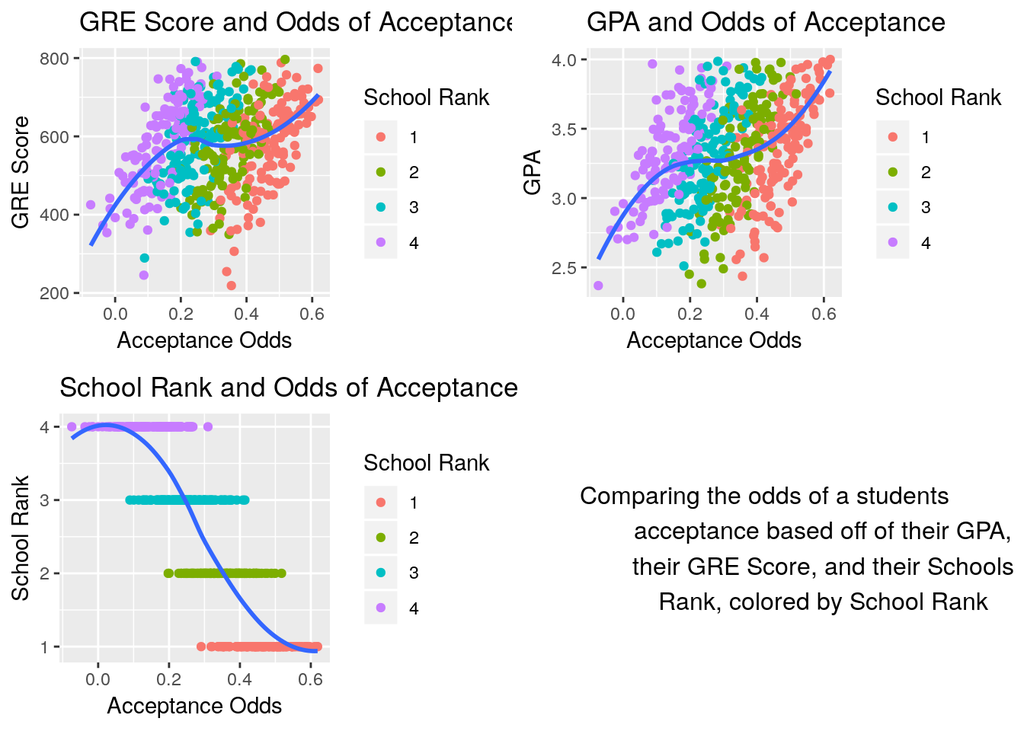

These graphs are made off of a random data set that had similar mean and standard deviation as the original data set. I find it incredibly interesting that out of the three influencing variables, the one that has the most influence is school rank. There are clear colored devisions, that despite similar scores, they have vastly differently likelyhoods of acceptance based on school rank. Which means there are vastly different likelyhoods based on a students, and more especially their parents, wealth.

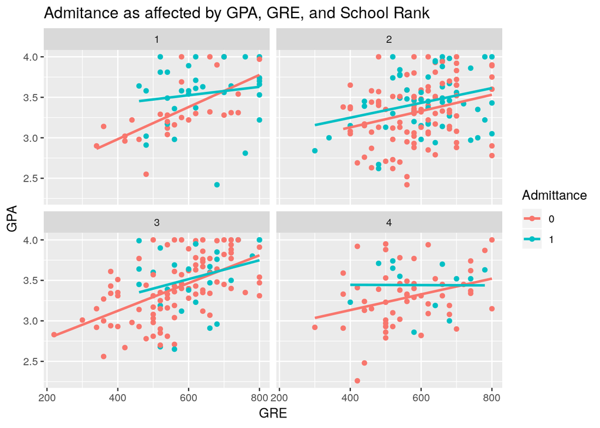

This is the most interesting graph I found while looking at the original data set. The thing I find more interesting is that in a tier 4 school, there was a student with a 4.0 and a 800 gre that was not accepted into grad school, while in the other 3 tiers there was a student with similar scores that was accepted.